# Simulation 2

Tianyi Liu

2023-07-07

```r
# source("a01_extended_dSVA.R")
source("s02_simulation_functions.R")
library(extraDistr)
library(statmod)
library(MASS)
library(dplyr)
library(tidyr)
library(statmod)
set.seed(100)
```

We aim at finding a simulation parameter setting where latent variables can carry significant variations as compared to that carried by the regression parameters, such that using dSVA can prove to be beneficial.

$$\mathbf{Y} = \mathbf{\Theta}\mathbf{P} + \mathbf{Z}\mathbf{D} +
\mathbf{E}, \\
\mathbf{P} \geq 0, \\
\mathbf{P}^T \mathbf{1} = \mathbf{1}.$$
* $n$: number of samples; * $m$: number of genes ($m >> n$); * $K$: number of cell types; * $\lambda$: controls the gene expression cell-type specificity; * $\mu$: control the size of the second and third latent parameters; * $\sigma$: control the variance of latent parameters;

Create an error-free model $\mathbf{E} = \mathbf{0}$ first:

- $\mathbf{x}_j^T \sim \pi(W \cdot {\rm dir}(1, 1, \dots, 1) + (1 - W) \cdot {\rm dir}(\lambda, 1, \dots, 1) )$, $W \sim Ber(p_{\rm sig})$, and $\pi$ is a sampling operator;
- $\mathbf{p}_i \sim {\rm dir}(\alpha_{i1}, \dots, \alpha_{iK})$;
- $\mathbf{d}^T_1 = (0, \dots. 0, 1, \dots, 1)^T$ ($n/2$ $0$s and $1$s each).
- $\mathbf{d}^T_2 = (0, \dots. 0, 1, \dots, 1, 0, \dots. 0, 1, \dots, 1)^T$ ($n/4$ $0$s and $1$s each).
- $\mathbf{d}^T_3 = \mathbf{1} - \mathbf{d}^T_2$.
- $z_{1j} \sim N(0, \sigma^2/K^4)$.
- $z_{2j} \sim N(-\mu/K^2, \sigma^2/K^4)$.
- $z_{3j} \sim N(\mu/K^2, \sigma^2/K^4)$.

```
  D[1, ] <- c(rep(0, floor(n/2)), rep(1, ceiling(n/2)))
  D[2, ] <- rep(c(rep(0, floor(n/4)), rep(1, ceiling(n/4))), 2)
  D[3, ] <- 1 - D[2, ]
  Z[, 1] <- rnorm(m, 0, sigma/K^2)
  Z[, 2] <- rnorm(m, -mu/K^2, sigma/K^2)
  Z[, 3] <- rnorm(m, mu/K^2, sigma/K^2)
```

```r
n <- 20
m <- 2000
K <- 5
p <- 3
p_sig <- 0.5
lambda <- 3
mu_seq <- seq(0, 9, 3)
sigma <- 4
```

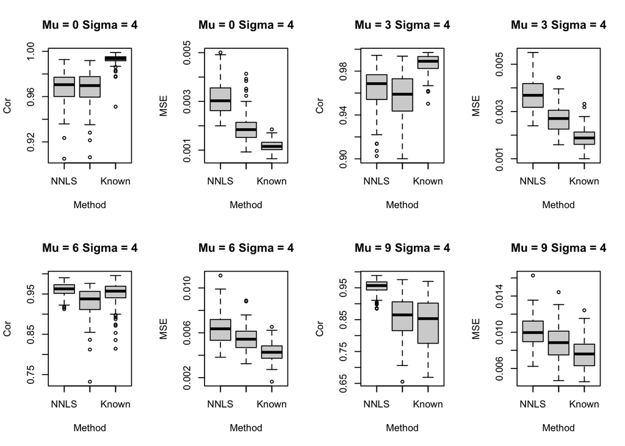

```r
n <- 20
m <- 2000
K <- 5
p <- 3
p_sig <- 0.5
lambda <- 3
mu <- 5
sigma_seq <- seq(3, 12, 3)
```

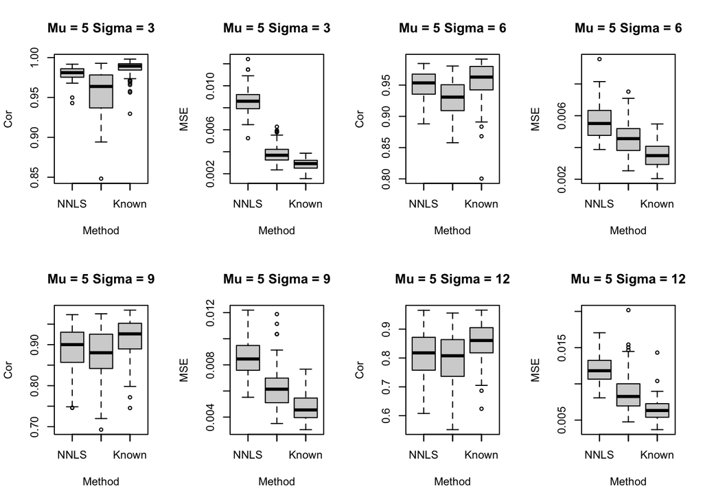